# R Notebook

## Data

```r
s_ex03p03_data_path <- "https://charlotte-ngs.github.io/asmss2022/data/asm_bw_flem.csv"
s_ex03p03_data_path <- file.path(here::here(), "docs", "data", "asm_bw_flem.csv")
tbl_ex03p03_data <- readr::read_csv(file = s_ex03p03_data_path)
```

## Least Squares Normal Equations

In this section, we are computing one solution for the Least Squares Normal Equation. First sort the data according to the breed

```r
tbl_ex03p03_data <- tbl_ex03p03_data[order(tbl_ex03p03_data$Breed),]
```

```r
mat_X <- model.matrix(lm(`Body Weight` ~ 0 + Breed, data = tbl_ex03p03_data))
mat_X <- cbind(matrix(1, nrow = nrow(tbl_ex03p03_data), ncol = 1), mat_X)
dimnames(mat_X) <- NULL
mat_xtx <- crossprod(mat_X)
mat_xtx
```

```
     [,1] [,2] [,3] [,4]
[1,]   10    3    4    3
[2,]    3    3    0    0
[3,]    4    0    4    0
[4,]    3    0    0    3
```

The MP generalized inverse is obtained by

```r
mat_xtx_ginv <- MASS::ginv(mat_xtx)
mat_xtx_ginv
```

```
            [,1]        [,2]         [,3]        [,4]
[1,] 0.057291667  0.02604167  0.005208333  0.02604167
[2,] 0.026041667  0.22395833 -0.088541667 -0.10937500
[3,] 0.005208333 -0.08854167  0.182291667 -0.08854167
[4,] 0.026041667 -0.10937500 -0.088541667  0.22395833
```

The right hand side

```r
vec_y <- tbl_ex03p03_data$`Body Weight`
mat_xty <- crossprod(mat_X, vec_y)
mat_xty
```

```
     [,1]
[1,] 4952
[2,] 1404
[3,] 2080
[4,] 1468
```

One solution is obtained by

```r
mat_b0 <- crossprod(mat_xtx_ginv, mat_xty)
mat_b0
```

```
          [,1]
[1,] 369.33333
[2,]  98.66667
[3,] 150.66667
[4,] 120.00000
```

Setting the components of this solution vector $b^0$ equal to

$$b^0 = \begin{bmatrix} \mu \\\alpha_1 \\\alpha_2 \\\alpha_3\end{bmatrix}$$

## Default Contrasts

By default the `lm()` function uses the so-called **treatment** contrasts. This means that all levels of a factor are compared to the first level when sorting the levels alphabetically. The first level is interpreted as a control case where all other levels are interpreted as different treatments which are compared to the control.

In what follows, we try to show how the solutions of the normal equations are related to the results obtained by `lm()`. If we wanted to see what type of estimable functions are used by the `lm()` function, it can be derived from the ouput of the function `contrasts()`. For our example with the Breed, we obtain the contrast matrix by

```r
contrasts(as.factor(tbl_ex03p03_data$Breed))
```

```
          Limousin Simmental
Angus            0         0
Limousin         1         0
Simmental        0         1
```

This means that the effect reported as `Limousin` by `lm()` corresponds to the first estimable function and the effect reported as `Simmental` corresponds to the second estimable function. What the estimable functions are, we obtain from the computations that follow below. The effect for `Angus` is contained in the intercept which is just set to the mean body weight of all Angus animals.

Adding to the above contrast matrix a row of all ones to the left side and inverting the extended matrix gives

```r
mat_contr <- contrasts(as.factor(tbl_ex03p03_data$Breed))
mat_contr <- cbind(matrix(1, nrow = nrow(mat_contr), ncol = 1), mat_contr)
mat_contr
```

```
            Limousin Simmental
Angus     1        0         0
Limousin  1        1         0
Simmental 1        0         1
```

Inverting the above shown contrast matrix yields the matrix with estimable functions

```r
mat_estf <- solve(mat_contr)
row.names(mat_estf)[1] <- "(Intercept)"
mat_estf
```

```
            Angus Limousin Simmental
(Intercept)     1        0         0
Limousin       -1        1         0
Simmental      -1        0         1
```

The frist row of the above matrix shows that the intercept corresponds to the mean of all Angus animals. This can be verified by

```r
n_inter_dummy <- mean(tbl_ex03p03_data[tbl_ex03p03_data$Breed == "Angus", ]$`Body Weight`)
n_inter_dummy
```

```
[1] 468
```

The linear model yields

```r
lm_ex03p03 <- lm(`Body Weight` ~ Breed, data = tbl_ex03p03_data)
coefficients(lm_ex03p03)["(Intercept)"]
```

```
(Intercept)
        468
```

The second and the third row of the above shown matrix of estimable functions contain the vector $q^T$ for the effect that are given as rownames. For example for the effect `Limousin` the row-vector $q^T_{LI}$ is

$$q_{LI} = \begin{bmatrix} 0 \\-1 \\1 \\0\end{bmatrix}$$

This means that the effect for Limousin shown in the output of `lm()` corresponds to the difference between $\alpha_2 - \alpha_1$. This is obtained by multiplying $q^T_{LI}$ with $b^0$, hence

$$q^T_{LI} \cdot b^0 = \alpha_2 - \alpha_1$$

The numerical solution for the effect of `BreedLimousin` is computed as

```r
eff_LI <- mat_b0[3] - mat_b0[2]
eff_LI
```

```
[1] 52
```

The solution from `lm()` is

```r
coefficients(lm_ex03p03)["BreedLimousin"]
```

```
BreedLimousin
           52
```

Similarly for the effect of Simmental. The estimable function is determined by the third row of the matrix of estimable functions.

$$q_{SI} = \begin{bmatrix} 0 \\-1 \\0 \\1\end{bmatrix}$$

That means, the effect for Simmental is computed as $q^T_{SI} \cdot b^0$ corresponds to the difference between $\alpha_3$ and $\alpha_1$.

```r
eff_SI <- mat_b0[4] - mat_b0[2]
eff_SI
```

```
[1] 21.33333
```

The solution from `lm()`

```r
coefficients(lm_ex03p03)["BreedSimmental"]
```

```
BreedSimmental
      21.33333
```

Combining, the two estimable functions into a vector $c$

$$c = \begin{bmatrix} \alpha_2 - \alpha_1 \\\alpha_3 - \alpha_1\end{bmatrix}$$

## Alternative Contrasts

One possible alternative for the default treatment contrasts are the sequential difference contrasts. These can be activated by changing the options of the current R-session with the following command

```r
opts <- options()
options(contrasts = c("contr.sdif", "contr.sdif"))
getOption("contrasts")
```

```
[1] "contr.sdif" "contr.sdif"
```

With the sequential difference contrasts, we are looking at the pair-wise differences of the levels. In order to construct the contrast matrix for the sequential different contrasts, the R-package MASS is required and the contrast matrix looks as follows

```r
library(MASS)
(cmat_sdiff <- contrasts(as.factor(tbl_ex03p03_data$Breed)))
```

```
          Limousin-Angus Simmental-Limousin
Angus         -0.6666667         -0.3333333
Limousin       0.3333333         -0.3333333
Simmental      0.3333333          0.6666667
```

From the contrast matrix, we can try to infer the estimable functions by adding a column of ones to the left of the matrix and the compute the inverse of that extended contrast matrix.

```r
ecmat_sdiff <- cbind(matrix(1, nrow = nrow(cmat_sdiff), ncol = 1), cmat_sdiff)
ecmat_sdiff
```

```
            Limousin-Angus Simmental-Limousin
Angus     1     -0.6666667         -0.3333333
Limousin  1      0.3333333         -0.3333333
Simmental 1      0.3333333          0.6666667
```

The inverse of ecmat_sdiff

```r
est_mat_sdiff <- solve(ecmat_sdiff)
row.names(est_mat_sdiff)[1] <- "(Intercept)"
est_mat_sdiff
```

```
                        Angus   Limousin Simmental
(Intercept)         0.3333333  0.3333333 0.3333333
Limousin-Angus     -1.0000000  1.0000000 0.0000000
Simmental-Limousin  0.0000000 -1.0000000 1.0000000
```

The first row of the above matrix shows how the intercept is computed from the class means. With the first row all having a value of $1/k$ for $k$ being the number of levels, it follows that the intercept here is computed as the mean over all class means

```r
n_mean_angus <- mean(tbl_ex03p03_data[tbl_ex03p03_data$Breed == "Angus", ]$`Body Weight`)
n_mean_limousin <- mean(tbl_ex03p03_data[tbl_ex03p03_data$Breed == "Limousin", ]$`Body Weight`)
n_mean_simmental <- mean(tbl_ex03p03_data[tbl_ex03p03_data$Breed == "Simmental", ]$`Body Weight`)
mean(c(n_mean_angus, n_mean_limousin,n_mean_simmental))
```

```
[1] 492.4444
```

The intercept is

```r
lm_sdiff <- lm(formula = `Body Weight` ~ Breed, data = tbl_ex03p03_data)
coefficients(lm_sdiff)["(Intercept)"]
```

```
(Intercept)
   492.4444
```

The second and the third row of `est_mat_sdiff` show the estimable functions that are used to compute the reported effects from the solutions of the normal equations. So the effect `Limousin-Angus` is computed from the difference between $\alpha_2-\alpha_1$

```r
mat_b0[3] - mat_b0[2]
```

```
[1] 52
```

The effect from `lm()`

```r
coefficients(lm_sdiff)["BreedLimousin-Angus"]
```

```
BreedLimousin-Angus
                 52
```

Similarly for `Simmental-Limousin`

```r
mat_b0[4] - mat_b0[3]
```

```
[1] -30.66667
```

The effect from `lm()`

```r
coefficients(lm_sdiff)["BreedSimmental-Limousin"]
```

```
BreedSimmental-Limousin
              -30.66667
```

Finally, we have to re-set the options

```r
options(opts)
getOption("contrasts")
```

```
        unordered           ordered
"contr.treatment"      "contr.poly"
```

## Example from Video https://youtu.be/eVSIDf5w1_I

```r
data("OrchardSprays")
str(OrchardSprays)
```

```
'data.frame':   64 obs. of  4 variables:
 $ decrease : num  57 95 8 69 92 90 15 2 84 6 ...
 $ rowpos   : num  1 2 3 4 5 6 7 8 1 2 ...
 $ colpos   : num  1 1 1 1 1 1 1 1 2 2 ...
 $ treatment: Factor w/ 8 levels "A","B","C","D",..: 4 5 2 8 7 6 3 1 3 2 ...
```

Plot

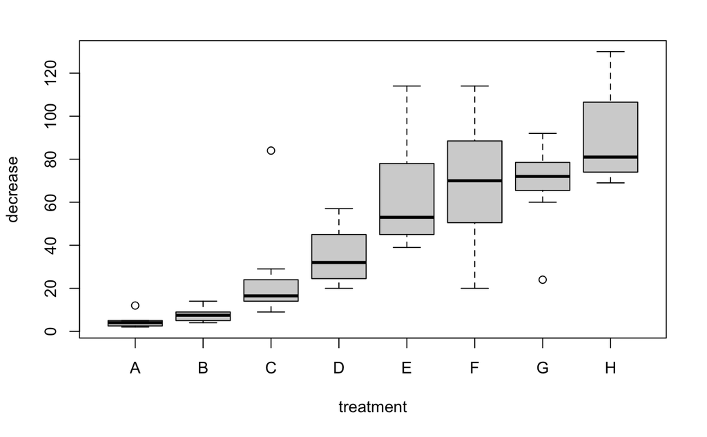

```r
plot(decrease ~ treatment, data = OrchardSprays)
```

```r
model1 <- lm(decrease ~treatment, data = OrchardSprays)
summary(model1)
```

```
Call:
lm(formula = decrease ~ treatment, data = OrchardSprays)

Residuals:
    Min      1Q  Median      3Q     Max
-49.000  -9.500  -1.625   3.812  58.750

Coefficients:
            Estimate Std. Error t value Pr(>|t|)
(Intercept)    4.625      7.253   0.638  0.52631
treatmentB     3.000     10.258   0.292  0.77101
treatmentC    20.625     10.258   2.011  0.04918 *
treatmentD    30.375     10.258   2.961  0.00449 **
treatmentE    58.500     10.258   5.703 4.60e-07 ***
treatmentF    64.375     10.258   6.276 5.39e-08 ***
treatmentG    63.875     10.258   6.227 6.48e-08 ***
treatmentH    85.625     10.258   8.347 2.08e-11 ***
---
Signif. codes:  0 ‘***’ 0.001 ‘**’ 0.01 ‘*’ 0.05 ‘.’ 0.1 ‘ ’ 1

Residual standard error: 20.52 on 56 degrees of freedom
Multiple R-squared:  0.7044,    Adjusted R-squared:  0.6674
F-statistic: 19.06 on 7 and 56 DF,  p-value: 9.499e-13
```

Use heterogeneous variance for different treatement classes using gls in model3

```r
library(nlme)
model2 <- gls(decrease~treatment, data = OrchardSprays)
model3 <- update(model2, weights=varIdent(form=~1|treatment))
AIC(model2, model3)
```

|  | df | AIC |
| --- | --- | --- |
| model2 | 9 | 531.9289 |
| model3 | 16 | 501.6458 |

```r
summary(model3)
```

```
Generalized least squares fit by REML
  Model: decrease ~ treatment
  Data: OrchardSprays
```

|  | AIC | BIC | logLik |
| --- | --- | --- | --- |
|  | 501.6458 | 534.0515 | -234.8229 |

```
Variance function:
 Structure: Different standard deviations per stratum
 Formula: ~1 | treatment
 Parameter estimates:
        D         E         B         H         G         F         C         A
1.0000000 2.0025451 0.2450055 1.8026660 1.4989448 2.1721775 1.8179616 0.2384599

Coefficients:
```

|  | Value | Std.Error | t-value | p-value |
| --- | --- | --- | --- | --- |
| (Intercept) | 4.625 | 1.132909 | 4.082412 | 0.0001 |
| treatmentB | 3.000 | 1.624313 | 1.846935 | 0.0700 |
| treatmentC | 20.625 | 8.711010 | 2.367693 | 0.0214 |
| treatmentD | 30.375 | 4.884149 | 6.219098 | 0.0000 |
| treatmentE | 58.500 | 9.581186 | 6.105716 | 0.0000 |
| treatmentF | 64.375 | 10.381883 | 6.200706 | 0.0000 |
| treatmentG | 63.875 | 7.210948 | 8.858059 | 0.0000 |
| treatmentH | 85.625 | 8.638964 | 9.911490 | 0.0000 |

```
 Correlation:
           (Intr) trtmnB trtmnC trtmnD trtmnE trtmnF trtmnG
treatmentB -0.697
treatmentC -0.130  0.091
treatmentD -0.232  0.162  0.030
treatmentE -0.118  0.082  0.015  0.027
treatmentF -0.109  0.076  0.014  0.025  0.013
treatmentG -0.157  0.110  0.020  0.036  0.019  0.017
treatmentH -0.131  0.091  0.017  0.030  0.016  0.014  0.021

Standardized residuals:
       Min         Q1        Med         Q3        Max
-2.2092755 -0.5900360 -0.1950474  0.3287518  2.4049091

Residual standard error: 13.43769
Degrees of freedom: 64 total; 56 residual
```

Succesive difference contrasts

Save old options

```r
opts <- options()
getOption("contrasts")
```

```
        unordered           ordered
"contr.treatment"      "contr.poly"
```

Change contrasts and run model

```r
library(MASS)
options(contrasts = c("contr.sdif", "contr.sdif"))
model4 <- gls(decrease ~ treatment, data = OrchardSprays)
model5 <- update(model4,  weights=varIdent(form=~1|treatment))
summary(model5)
```

```
Generalized least squares fit by REML
  Model: decrease ~ treatment
  Data: OrchardSprays
```

|  | AIC | BIC | logLik |
| --- | --- | --- | --- |
|  | 501.6458 | 534.0515 | -234.8229 |

```
Variance function:
 Structure: Different standard deviations per stratum
 Formula: ~1 | treatment
 Parameter estimates:
        D         E         B         H         G         F         C         A
1.0000000 2.0025451 0.2450055 1.8026660 1.4989448 2.1721775 1.8179616 0.2384599

Coefficients:
```

|  | Value | Std.Error | t-value | p-value |
| --- | --- | --- | --- | --- |
| (Intercept) | 45.42187 | 2.564439 | 17.712209 | 0.0000 |
| treatmentB-A | 3.00000 | 1.624313 | 1.846935 | 0.0700 |
| treatmentC-B | 17.62500 | 8.715109 | 2.022350 | 0.0479 |
| treatmentD-C | 9.75000 | 9.857466 | 0.989098 | 0.3269 |
| treatmentE-D | 28.12500 | 10.634240 | 2.644759 | 0.0106 |
| treatmentF-E | 5.87500 | 14.036226 | 0.418560 | 0.6771 |
| treatmentG-F | -0.50000 | 12.538512 | -0.039877 | 0.9683 |
| treatmentH-G | 21.75000 | 11.138334 | 1.952716 | 0.0559 |

```
 Correlation:
             (Intr) trtB-A trtC-B trtD-C trtE-D trtF-E trtG-F
treatmentB-A  0.002
treatmentC-B  0.410 -0.096
treatmentD-C -0.257  0.000 -0.868
treatmentE-D  0.311  0.000  0.000 -0.215
treatmentF-E  0.056  0.000  0.000  0.000 -0.606
treatmentG-F -0.217  0.000  0.000  0.000  0.000 -0.605
treatmentH-G  0.099  0.000  0.000  0.000  0.000  0.000 -0.363

Standardized residuals:
       Min         Q1        Med         Q3        Max
-2.2092755 -0.5900360 -0.1950474  0.3287518  2.4049091

Residual standard error: 13.43769
Degrees of freedom: 64 total; 56 residual
```

Re-set options

```r
options(opts)
```

## Example from https://bookdown.org/pingapang9/linear_models_bookdown/chap-contrasts.html

```r
library(dplyr)
library(broom)
data("PlantGrowth")
PlantGrowth %>%
  filter(group != "ctrl") %>%
  lm(weight ~ group, .) %>%
  tidy()
```

| term | estimate | std.error | statistic | p.value |
| --- | --- | --- | --- | --- |
| (Intercept) | 4.661 | 0.2031985 | 22.938167 | 8.928038e-15 |
| grouptrt2 | 0.865 | 0.2873660 | 3.010099 | 7.518426e-03 |

## Example from https://marissabarlaz.github.io/portfolio/contrastcoding/

Examples from the mentioned website are applied to our extended dataset assigned to `tbl_ex03p03_data`.

### Dummy Coding

The coding scheme that is most familiar is the dummy coding or the treatment coding. In that coding all levels are compares to a reference level. The reference is the level that is first in an alphabetical order. The contrast matrix for a factor with four levels looks as follows

```r
contr.treatment(4)
```

```
  2 3 4
1 0 0 0
2 1 0 0
3 0 1 0
4 0 0 1
```

Checking the contrasts for the dummy variables `Breed` and `BCS` after conversion to factors, gives

```r
tbl_ex03p03_data$Breed <- as.factor(tbl_ex03p03_data$Breed)
tbl_ex03p03_data$BCS <- as.integer(tbl_ex03p03_data$BCS)
tbl_ex03p03_data$BCS <- as.factor(tbl_ex03p03_data$BCS)
```

Contrasts for `Breed`

```r
contrasts(tbl_ex03p03_data$Breed)
```

```
          Limousin Simmental
Angus            0         0
Limousin         1         0
Simmental        0         1
```

Extending the contrasts matrix

```r
con_mat <- contrasts(tbl_ex03p03_data$Breed)
con_mat
```

```
          Limousin Simmental
Angus            0         0
Limousin         1         0
Simmental        0         1
```

The extension is by a row of ones which stands for the intercept

```r
con_mat <- cbind(matrix(1, nrow = nrow(con_mat), ncol = 1), con_mat)
con_mat
```

```
            Limousin Simmental
Angus     1        0         0
Limousin  1        1         0
Simmental 1        0         1
```

```r
est_mat <- solve(con_mat)
est_mat
```

```
          Angus Limousin Simmental
              1        0         0
Limousin     -1        1         0
Simmental    -1        0         1
```

Contrasts for `BCS`

```r
contrasts(tbl_ex03p03_data$BCS)
```

```
  4 5 6
3 0 0 0
4 1 0 0
5 0 1 0
6 0 0 1
```

The contrasts can be changed by an assignment

```r
nr_breed <- nlevels(tbl_ex03p03_data$Breed)
contrasts(tbl_ex03p03_data$Breed) <- contr.treatment(nr_breed)
lm_bwbrbcs <- lm(`Body Weight` ~ Breed + BCS, data = tbl_ex03p03_data)
summary(lm_bwbrbcs)
```

```
Call:
lm(formula = `Body Weight` ~ Breed + BCS, data = tbl_ex03p03_data)

Residuals:
         1          2          3          4          5          6          7          8          9         10
-4.441e-16 -6.100e+00  6.100e+00 -3.300e+00 -1.030e+01 -6.100e+00  1.970e+01 -5.000e+00  5.594e-16  5.000e+00

Coefficients:
            Estimate Std. Error t value Pr(>|t|)
(Intercept)   463.90      10.80  42.948 1.76e-06 ***
Breed2         52.20      11.55   4.521   0.0107 *
Breed3         16.90      14.14   1.195   0.2981
BCS4            5.20      11.55   0.450   0.6758
BCS5            7.10      16.83   0.422   0.6949
BCS6           15.20      19.58   0.776   0.4809
---
Signif. codes:  0 ‘***’ 0.001 ‘**’ 0.01 ‘*’ 0.05 ‘.’ 0.1 ‘ ’ 1

Residual standard error: 12.91 on 4 degrees of freedom
Multiple R-squared:  0.8802,    Adjusted R-squared:  0.7304
F-statistic: 5.876 on 5 and 4 DF,  p-value: 0.05547
```

Changing to a different reference level

```r
contrasts(tbl_ex03p03_data$Breed) <- contr.treatment(nr_breed, base = nr_breed)
contrasts(tbl_ex03p03_data$Breed)
```

```
          1 2
Angus     1 0
Limousin  0 1
Simmental 0 0
```

```r
lm_bwbrbcs2 <- lm(`Body Weight` ~ Breed + BCS, data = tbl_ex03p03_data)
summary(lm_bwbrbcs2)
```

```
Call:
lm(formula = `Body Weight` ~ Breed + BCS, data = tbl_ex03p03_data)

Residuals:
         1          2          3          4          5          6          7          8          9         10
 4.663e-15 -6.100e+00  6.100e+00 -3.300e+00 -1.030e+01 -6.100e+00  1.970e+01 -5.000e+00 -1.988e-15  5.000e+00

Coefficients:
            Estimate Std. Error t value Pr(>|t|)
(Intercept)   480.80      14.72  32.663 5.24e-06 ***
Breed1        -16.90      14.14  -1.195   0.2981
Breed2         35.30      11.55   3.057   0.0378 *
BCS4            5.20      11.55   0.450   0.6758
BCS5            7.10      16.83   0.422   0.6949
BCS6           15.20      19.58   0.776   0.4809
---
Signif. codes:  0 ‘***’ 0.001 ‘**’ 0.01 ‘*’ 0.05 ‘.’ 0.1 ‘ ’ 1

Residual standard error: 12.91 on 4 degrees of freedom
Multiple R-squared:  0.8802,    Adjusted R-squared:  0.7304
F-statistic: 5.876 on 5 and 4 DF,  p-value: 0.05547
```

## Consecutive Differences

```r
contr.treatment(3)
```

```
  2 3
1 0 0
2 1 0
3 0 1
```

```r
contr.sdif(3)
```

```
         2-1        3-2
1 -0.6666667 -0.3333333
2  0.3333333 -0.3333333
3  0.3333333  0.6666667
```

Extending the sdif contrast

```r
mat_sdif <- contr.sdif(3)
mat_sdif <- cbind(matrix(1, nrow = nrow(mat_sdif), ncol = 1), mat_sdif)
mat_sdif
```

```
           2-1        3-2
1 1 -0.6666667 -0.3333333
2 1  0.3333333 -0.3333333
3 1  0.3333333  0.6666667
```

Estimable function

```r
mat_est_sdif <- solve(mat_sdif)
mat_est_sdif
```

```
             1          2         3
     0.3333333  0.3333333 0.3333333
2-1 -1.0000000  1.0000000 0.0000000
3-2  0.0000000 -1.0000000 1.0000000
```

```r
contr.sum(3)
```

```
  [,1] [,2]
1    1    0
2    0    1
3   -1   -1
```

```r
mat_sum <- contr.sum(3)
mat_sum <- cbind(matrix(1, nrow = nrow(mat_sum), ncol = 1), mat_sum)
mat_sum
```

```
  [,1] [,2] [,3]
1    1    1    0
2    1    0    1
3    1   -1   -1
```

```r
mat_est_sum <- solve(mat_sum)
mat_est_sum
```

```
              1          2          3
[1,]  0.3333333  0.3333333  0.3333333
[2,]  0.6666667 -0.3333333 -0.3333333
[3,] -0.3333333  0.6666667 -0.3333333
```

## Example from https://stats.oarc.ucla.edu/r/library/r-library-contrast-coding-systems-for-categorical-variables/

Reading the data

```r
hsb2 = read.table('https://stats.idre.ucla.edu/stat/data/hsb2.csv', header=T, sep=",")
str(hsb2)
```

```
'data.frame':   200 obs. of  11 variables:
 $ id     : int  70 121 86 141 172 113 50 11 84 48 ...
 $ female : int  0 1 0 0 0 0 0 0 0 0 ...
 $ race   : int  4 4 4 4 4 4 3 1 4 3 ...
 $ ses    : int  1 2 3 3 2 2 2 2 2 2 ...
 $ schtyp : int  1 1 1 1 1 1 1 1 1 1 ...
 $ prog   : int  1 3 1 3 2 2 1 2 1 2 ...
 $ read   : int  57 68 44 63 47 44 50 34 63 57 ...
 $ write  : int  52 59 33 44 52 52 59 46 57 55 ...
 $ math   : int  41 53 54 47 57 51 42 45 54 52 ...
 $ science: int  47 63 58 53 53 63 53 39 58 50 ...
 $ socst  : int  57 61 31 56 61 61 61 36 51 51 ...
```

Create a new variable

```r
hsb2$race.f = factor(hsb2$race, labels=c("Hispanic", "Asian", "African-Am", "Caucasian"))
```

Descriptive statistics

```r
tapply(hsb2$write, hsb2$race.f, mean)
```

```
  Hispanic      Asian African-Am  Caucasian
  46.45833   58.00000   48.20000   54.05517
```

Plot

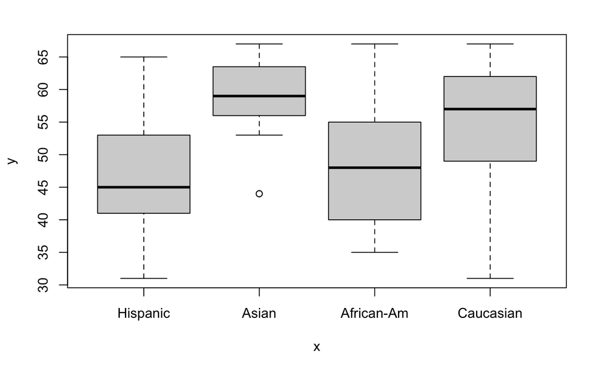

```r
plot(hsb2$race.f, hsb2$write)
```

### Dummy Coding

Comparison of each level of categorical variable to a reference.

```r
(contrasts(hsb2$race.f) = contr.treatment(4))
```

```
  2 3 4
1 0 0 0
2 1 0 0
3 0 1 0
4 0 0 1
```

```r
summary(lm(write ~ race.f, hsb2))
```

```
Call:
lm(formula = write ~ race.f, data = hsb2)

Residuals:
     Min       1Q   Median       3Q      Max
-23.0552  -5.4583   0.9724   7.0000  18.8000

Coefficients:
            Estimate Std. Error t value Pr(>|t|)
(Intercept)   46.458      1.842  25.218  < 2e-16 ***
race.f2       11.542      3.286   3.512 0.000552 ***
race.f3        1.742      2.732   0.637 0.524613
race.f4        7.597      1.989   3.820 0.000179 ***
---
Signif. codes:  0 ‘***’ 0.001 ‘**’ 0.01 ‘*’ 0.05 ‘.’ 0.1 ‘ ’ 1

Residual standard error: 9.025 on 196 degrees of freedom
Multiple R-squared:  0.1071,    Adjusted R-squared:  0.0934
F-statistic: 7.833 on 3 and 196 DF,  p-value: 5.785e-05
```

## Resources

https://www.r-bloggers.com/2015/01/using-and-interpreting-different-contrasts-in-linear-models-in-r/ https://rcompanion.org/rcompanion/h_01.html https://bookdown.org/pingapang9/linear_models_bookdown/chap-contrasts.html https://marissabarlaz.github.io/portfolio/contrastcoding/ https://www.uvm.edu/~statdhtx/StatPages/R/ContrastsInR.html https://cran.r-project.org/web/packages/multcomp/vignettes/multcomp-examples.pdf https://stats.stackexchange.com/questions/78354/what-is-a-contrast-matrix https://stats.oarc.ucla.edu/r/library/r-library-contrast-coding-systems-for-categorical-variables/ https://talklab.psy.gla.ac.uk/simgen/index.html

https://youtu.be/eVSIDf5w1_I https://youtu.be/qQHNRaBbR90 https://youtu.be/fXDNBeY2qp0